# stratR vignette

J. Shekeine

2016-05-17

# Introduction

This vignette illustrates, using practical examples, how to use the `stratR` package to construct stratigraphic diagrams of multiple variables. Differences in statistical properties amongst variables in large time-series datasets can make it difficult visualise such datasets in a way that is accurate, legible and that allows simultaneous comparison of all variables of interest.

`stratR` uses R’s `ggplot2` and `gridExtra` libraries to build high quality stratigraphic plots of multiple variables that are as well easily customisable. It takes care of the numerous fiddly details that would make building such a plot a nighmare and provides an intuitive function interface from which key plotting parameters can be modified easily. Plotting is done using the `stratPlot` function. See `?strapPlot` for full information on the function, its arguments etc.

In addition to the plotting function, `stratR`, through its `hscorer` function, provides a fast way to compute occurence metrics such as percentages and scores for paleoenviromental data. Like `stratPlot`, the function was designed with pollen stratigraphic data in mind, but can be used on time-series data as well.

## Plotting with stratPlot

### Preparing your data

#### Load and describe input data

Usually, raw data that is to be plotted or analysed in R will be in the [wide](https://en.wikipedia.org/wiki/Wide_and_narrow_data) format i.e., samples run row-wise and each measured variable is in its own column. In this vignette, we’ll start with a sample dataset that is originally in this format. Below, we load and inspect a sample dataset from `stratR` that is in the wide format.

```r
#Read sample data from stratR
data("stratPlotData")

#Print dimensions
dim(stratPlotData)
```

```
## [1] 125 684
```

```r
#Metadata columns
metavars <- c('ids', 'entitynum', 'region', 'site',
              'londd', 'latdd', 'altitude', 'samplenum', 'agebp')

#Model output from some model
modvars <- "minD"

#Rainfall anomalies
precipvars <- c("JJAPdelta", "DJFPdelta")

#Temperature anomalies
tempvars <- c("JJATdelta", "DJFTdelta")
```

The rest of the columns, 670 in number, contain pollen percentages of 670 plant taxa that were observed in various pollen cores, which are uniquley identified by the `entitynum` column. Age levels at which pollen counts were observed in each pollen core i.e., entitynum, are indicated in the column `agebp`.

It would be too tedious to manually define what columns in the datasets constitute pollen counts as done earlier with other variable types. Therefore, we can say that every column not already in the metadata, model or climate variable lists is a pollen variable.

```r
#Pollen variables
pollvars <- names(stratPlotData)[!names(stratPlotData)%in%c(metavars, modvars, precipvars, tempvars)]
```

#### Reshape to long format

`stratPlot` expects the input dataset to be in long format. Currently, our input data is in the wide format. We need to “melt” it to long as follows.

```r
datL <- melt(data=stratPlotData, id.vars=metavars, variable.factor=F)
```

#### Define variable groups

We then need to define the variable types in the data by adding a new column with grouping labels. Doing this will help determine how different variable types are aggregated and accorded plotting parameters.

```r
#Define variable groups
datL[variable%in%precipvars, group:='Precipitation']
datL[variable%in%tempvars, group:='Temperature']
datL[variable%in%modvars, group:='Model']
datL[variable%in%pollvars, group:='Pollen taxa']
```

The resulting data table now has:

- the original metadata columns
- a column named “variable” with the identities of all measured variables i.e., climate, pollen, model variables
- a column named “value” indicating the observed value for the respective measured variable.
- a column named “group” indicating how the different variables are to be aggregated.

We can get a peek of our reshaped data by running:

```r
head(datL)
```

[output not shown]

#### Remove trace occurences

Since the pollen percentages in the dataset are occurence data, we might want to get rid of trace occurences e.g., by retaining only those pollen observations with rates above a certain thresh-hold, say, 1%. We can also get rid of columns we do not wish to plot.

```r
#Subset pollen observations with rates equal to or above 1%
poll_dt <- subset(x=datL, variable%in%pollvars & value >=1)

#Fill every sample (time point) where a variable (pollen taxon) was not observed with zero
poll_dt <- dcast(poll_dt,  ids + entitynum +
                     region + site + londd + latdd + altitude +
                     samplenum + group + agebp ~ variable, value.var='value', fill=0)

#Drop columns with data we dont want to plot, e.g., ones that represent unknown pollen taxa
poll_dt[, NA.:=NULL]

#Reshape pollen data back into the long format
poll_dt <- melt(poll_dt, id.vars=c(metavars, 'group'))

#Remove variables in each entity that do not occur at least once
poll_dt[, n:=sum(value>0), .(entitynum, variable)]
poll_dt <- poll_dt[n>=1]
poll_dt[, n:=NULL]
```

Below, we subset and combine the now ready pollen data subset with the rest of the variables.

```r
#Subset other non-pollen data i.e. climate and model variables
oth_dt <- subset(x=datL, !variable%in%pollvars)

#Merge processed pollen data with the other non-pollen data
datL <- rbindlist(list(poll_dt, oth_dt), use.names=T)
```

### Construct plot

`stratPlot` ingests a dataset of class `data.table` with the aforedescribed structure i.e., like `datL` and arguments to control how the output plot is built and styled. Details of `statPlot`’s arguments and their meanings can be viewed in the package’s documentation with `?stratPlot`. Below are some examples illustrating the function’s arguments and potential use cases.

#### Single plot

Our sample data currently contains data for 3 entities i.e., pollen cores. The `ids` column uniquely identifies each entity i.e., pollen core in the dataset and indicates the region associated with each entity. To check what and how many entity `ids` are in the dataset we can run:

```r
length(unique(datL[, ids]))  #Print number of unique entities
```

```
## [1] 3
```

```r
unique(datL[, ids])          #Print labels of unique entities
```

```
## [1] "Entity_33_Region_Europe"       "Entity_8_Region_North America"
## [3] "Entity_5_Region_China"
```

```r
datL_i <- subset(x=datL, ids=='Entity_33_Region_Europe')
```

```r
#Build plot
plt_ls <- stratPlot(dat=datL,
                   grpcol='group',
                   tymcol='agebp', varcol='variable', valcol='value', varord=c('med'),
                   grp_ord=c('Model', 'Precipitation', 'Temperature', 'Pollen taxa'),
                   grp_colours=c('grey40', 'blue', 'brown3','darkgreen'),
                   grp_geom=c('line', 'line', 'line','area'),
                   grp_bline=c(NA, 20, "med", "med"),
                   grp_vartype=c('MinD', 'SD', 'SD','Percentages'),
                   grp_const=c('Model', 'Precipitation', 'Temperature'),

                   xbrkint=c(NA, NA, 5, NA),
                   ybrkint=NA,

                   axs_tsize=10, var_tsize=18, grp_tsize=25, ptt_tsize=20,

                   plab='', ylab='Age BP',
                   pmargin=unit(c(0.05, 0, 0.1, 0), 'cm'),
                   maxw=5
                  )

#Get plot object
plot_obj <- plt_ls$plot

#Get plot width (in cm)
plot_width <- plt_ls$width
```

The constructed plot can be viewed on the R graphics device in two quick lines.

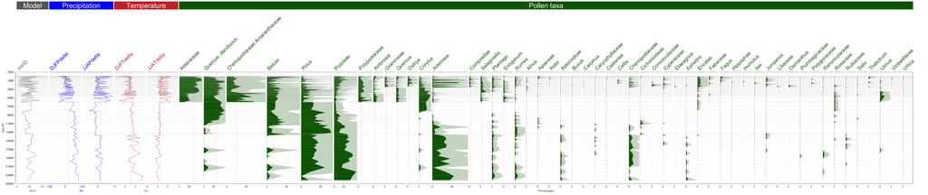

```r
#Draw plot
grid.newpage()
grid.draw(plot_obj)
```

To write the plot to file for later viewing or use in articles etc, we can use the `ggsave` function from `ggplot2` . To save to other formats, just change the extension of the output file name to the desired type e.g., png, tif, etc. Here, the plot is saved to the .pdf format.

```r
#Save plot as pdf
ggsave(filename=paste0("/tmp/", 'myplot.pdf'), plot=plot_obj,
       limitsize=F, width=plot_width, height=25, units='cm')
```

#### Multiple plots

To construct plots for multiple entities i.e., pollen cores, we can call `stratPlot` from within a `for loop` that will build a collection stratigraphic plots: one for each entity. These could be useful in various ways e.g., in comparing different entities, or, in generating a library of plots that can be used in an interactive map to query and view data at different locations.

##### Using sequential for loops

Our main dataset contains 3 entities.

```r
length(unique(datL[, ids]))  #Print number of unique entities
```

```
## [1] 3
```

```r
unique(datL[, ids])          #Print labels of unique entities
```

```
## [1] "Entity_33_Region_Europe"       "Entity_8_Region_North America"
## [3] "Entity_5_Region_China"
```

Each entitity’s data can be visualised using stratPlot with an ordinary for loop as follows:

```r
  for (entity in unique(stratPlotData[, ids])){

    #Isolate data for entity in the current iteration
    dat_ent <- datL[ids==entity]

    #Build plot
    plt_ls <- stratPlot(dat=dat_ent,
                       grpcol='group',
                       tymcol='agebp', varcol='variable', valcol='value', varord=c('med'),
                       grp_ord=c('Model', 'Precipitation', 'Temperature', 'Pollen taxa'),
                       grp_colours=c('grey40', 'blue', 'brown3','darkgreen'),
                       grp_geom=c('line', 'line', 'line','area'),
                       grp_bline=c(NA, 20, "med", "med"),
                       grp_vartype=c('MinD', 'SD', 'SD','Percentages'),
                       grp_const=c('Model', 'Precipitation', 'Temperature'),

                       xbrkint=c(NA, NA, 5, NA),
                       ybrkint=NA,

                       axs_tsize=10, var_tsize=18, grp_tsize=25, ptt_tsize=20,

                       plab=entity, ylab='Age BP',               #Note plab value here
                       pmargin=unit(c(0.05, 0, 0.1, 0), 'cm'),
                       maxw=5
                      )

    #Get plot object
    plot_obj <- plt_ls$plot

    #Get plot width (in cm)
    plot_width <- plt_ls$width

    #Make filename, replace "/tmp/" with the path you want your plots saved
    fname <- paste0("/tmp/", entity, ".pdf")

    #Save plot as pdf
    ggsave(filename=fname, plot=plot_obj,
           limitsize=F, width=plot_width, height=25, units='cm')

}
```

##### Using parallel for loops

In addition to the ordinary for loops, we can also exploit R’s parallel processing capabilities to speed up the generation of multiple plots. Note that to construct just one or two plots, an ordinary (sequential) `for loop` should be preffered for reasons explained [here](http://stackoverflow.com/questions/14614306/why-is-the-parallel-package-slower-than-just-using-apply.) As the number of plots to construct increases, say, beyond 5, running the task in parallel becomes a lot more efficient compared running the task sequanetially as the standard `for` loop does in R.

```r
  #Load libraries for parallel processing
  library('parallel')
  library('foreach')
  library('doParallel')
```

```r
  #Register cluster for parallel processing
  cl <- makeCluster(detectCores() - 1)
  registerDoParallel(cl, cores = detectCores() - 1)

  #Parallel for loop
  plotList <- foreach (entity=unique(stratPlotData[, ids]), .packages="stratR", .combine='c') %dopar% {

    #Isolate data for entity in the current iteration
    dat_ent <- datL[ids==entity]

    #Build plot
    plt_ls <- stratPlot(dat=dat_ent,
                       grpcol='group',
                       tymcol='agebp', varcol='variable', valcol='value', varord=c('med'),
                       grp_ord=c('Model', 'Precipitation', 'Temperature', 'Pollen taxa'),
                       grp_colours=c('grey40', 'blue', 'brown3','darkgreen'),
                       grp_geom=c('line', 'line', 'line','area'),
                       grp_bline=c(NA, 20, "med", "med"),
                       grp_vartype=c('MinD', 'SD', 'SD','Percentages'),
                       grp_const=c('Model', 'Precipitation', 'Temperature'),

                       xbrkint=c(NA, NA, 5, NA),
                       ybrkint=NA,

                       axs_tsize=10, var_tsize=18, grp_tsize=25, ptt_tsize=20,

                       plab=entity, ylab='Age BP',               #Note plab value here
                       pmargin=unit(c(0.05, 0, 0.1, 0), 'cm'),
                       maxw=5
                      )
    #Get result
    res <- list(plt_ls)
    names(res) <- entity
    return(res)
  }
  stopCluster(cl)
```

The object `plotList` created above is a nested list object containing a plot object for each entity processed as well as the respective width. Below, we access each plot object in the list and save it to disk at the respective width.

```r
 #Write plot objects to file
 for (entity in names(plotList)){

  #Get plot object in current iteration
  plot_obj <- plotList[[entity]]$plot

  #Get plot width (in cm)
  plot_width <- plotList[[entity]]$width

  #Make filename, replace "/tmp/" with the path you want your plots saved
  fname <- paste0("/tmp/", entity, "_par_.pdf")

  #Save plot as pdf
  ggsave(filename=fname, plot=plot_obj,
         limitsize=F, width=plot_width, height=25, units='cm')
 }
```

## Computing biome, pft scores with hscorer

The function `hscorer` computes pollen scores based on biome, PFT or other schemes. Though built for pollen data, it can be used or adapted for use to calculate occurence metrics for other paleoenvironmental data as well.

#### Preparing data

This function’s documentation (see `?hscorer`) explains the expected inputs datasets and what structure they should have. Here, we’ll get straight to work. `stratR` contains sample datasets that can be used as input for `hscorer` We can load them as follows:

```r
#Load sample pollen counts
data(p_counts) #Load a sample pcounts table (data.table of pollen counts)
head(p_counts) #Inspect: This dataset correponds to the expected value of the `pcounts` argument
```

```
##    entitynum samplenum varnum count
## 1:       221         1     32   346
## 2:       221         1     66    17
## 3:       221         1     80     2
## 4:       221         1     95   932
## 5:       221         1    124   143
## 6:       221         1    132     1
```

#### Multiple schemes

Occurence metrics can also be computed based on multiple schemes by using a `for` loop that iterates over the different schemes we have, outputting a result based on each scheme. The snippet below illustrates a use case where we want to generate occurence metrics based on several schemes.

```r
for(scheme in names(hschemes)){

    #Get i'th bscheme
    hscheme_i <- hschemes[[scheme]]

    #Compute occurence percentages and scores based on i'th scheme
    percs_scores_i  <- hscorer(pcounts=p_counts, hscheme=hscheme_i)

    #Make filenames, replace "/tmp/" with the path where you want your plots saved
    fname_percs <- paste0("/tmp/", "percentages_", scheme, ".csv")
    fname_scores <- paste0("/tmp/", "scores_", scheme, ".csv")

    #Write percentages to file
    write.csv(x=percs_scores_i$percentages, file=fname_percs, row.names=F)

    #Write occurence scores to file
    write.csv(x=percs_scores_i$scores, file=fname_scores, row.names=F)
  }
```

#### Plotting output with stratPlot

In conclusion, outputs from `hscorer` can be readily visualised with the `stratPlot` function. Below, we compute PFT percentages based on Peyron`s PFT scheme and plot the result with`stratPlot`.

```r
#Isolate peyron pft scheme
peyron_pft <- hschemes$Peyron_pft_scheme

#Compute taxon percentages
peyron_percs <- hscorer(pcounts=p_counts, hscheme=peyron_pft)$percentages

#Get the data ready for stratPlot

  #Subset data for just one entity
  dat <- peyron_percs[entitynum==221]

  #Melt to long format
  datm <- melt(dat, id.vars=c("entitynum", "samplenum"), variable.name="PFT")

  #Remove trace occurences (less than 1% rate)
  datm <- datm[value>1]

  #Fill every sample (time point) where a PFT was not observed with zero
  datm <- dcast(datm,  entitynum + samplenum ~ PFT, value.var='value', fill=0)

  #Reshape pollen data back into the long format
  datm <- melt(datm, id.vars=c("entitynum", 'samplenum'), variable.name="PFT")
```

We now need to add a grouping variable as expected by `stratPlot`. For demo purposes, we’ll just lump all the PFT’s in one artificial group. However, one could, for example, add biome data from a pft to biome translation table as the grouping variable so that the time-series of PFT percentages are plotted by biome.

```r
datm[, group:="Plant functional types"]
```

Finally, we can construct the plot as illustrated earlier as follows.

```r
#Plot
plt_ls <- stratPlot(dat=datm,
                       grpcol='group',
                       tymcol='samplenum', varcol='PFT', valcol='value', varord=c('med'),
                       grp_geom=c('area'),
                       grp_bline=0,
                       grp_vartype="Percentages",
                       grp_colours="darkgreen",

                       axs_tsize=10, var_tsize=18, grp_tsize=16, ptt_tsize=18,

                       plab="Entity 506", ylab='Sample',
                       pmargin=unit(c(0.05, 0, 0.1, 0), 'cm'),
                       maxw=5
                      )
#Get plot object
plot_obj <- plt_ls$plot

#Get plot width (in cm)
plot_width <- plt_ls$width
```

The generated plot can then be on the R device as follows.

[figure not shown]

```r
#Draw plot
grid.newpage()
grid.draw(plot_obj)
```